# Data visualization

Author

Patrick A. Singleton

### Objectives & outcomes

The objectives of this tutorial are to:

- Learn how to merge datasets together based on a common key/column.
- Learn how to process dates into a data format and extract information.
- Understand basic types of figures for displaying information about a single variable, multiple groups, and two variables.
- Practice creating figures to visualize data of different types.

At the end of this tutorial, you should be able to:

- Merge or join two datasets together based on a common key/column.
- Process dates and extract information.
- Determine which figures are appropriate for visualizing the following: the composition of a single categorical variable, the distribution of a single continuous variable, comparisons between two (or more) groups or variables, and relationships between two variables.
- Create basic versions of different figure types: bar chart, stacked bar chart, box plot, histogram, and scatter diagram.

### Transportation dataset

For this tutorial, we will use data from the *Logan non-motorized trail count data* project. The datasets include information on daily counts of non-motorized (walking and bicycling) traffic at two locations: along the Boulevard Trail in Logan (*Boulevard*), and along a trail in Green Canyon (*GreenCanyon*). There are also weather (*Weather*) and air quality (*AirQuality*) data for the same dates. You can access these data from the [Transportation datasets](https://github.com/singletonpa/usu-course-transport-data-research/blob/main/Data/Transportation_datasets.md) page on GitHub.

This time, instead of downloading the data and then loading it into Positron from somewhere on our computer, we will load the data directly from GitHub, using the direct link.

```r
# Load data from GitHub
Boulevard <- read.csv(file=url("https://raw.github.com/singletonpa/usu-course-transport-data-safety/main/Data/Logan_trail_counts/Boulevard.csv", method="libcurl"))
GreenCanyon <- read.csv(file=url("https://raw.github.com/singletonpa/usu-course-transport-data-safety/main/Data/Logan_trail_counts/GreenCanyon.csv", method="libcurl"))
Weather <- read.csv(file=url("https://raw.github.com/singletonpa/usu-course-transport-data-safety/main/Data/Logan_trail_counts/Weather.csv", method="libcurl"))
AirQuality <- read.csv(file=url("https://raw.github.com/singletonpa/usu-course-transport-data-safety/main/Data/Logan_trail_counts/AirQuality.csv", method="libcurl"))

# Inspect
str(Boulevard)
```

```
'data.frame':   730 obs. of  2 variables:
 $ Date : chr  "2018-01-01" "2018-01-02" "2018-01-03" "2018-01-04" ...
 $ Count: num  92 104 93 85 116 59 78 138 101 153 ...
```

```r
str(GreenCanyon)
```

```
'data.frame':   730 obs. of  2 variables:
 $ Date : chr  "2018-01-01" "2018-01-02" "2018-01-03" "2018-01-04" ...
 $ Count: num  134 46 37 30 39 87 69 42 26 14 ...
```

```r
str(Weather)
```

```
'data.frame':   730 obs. of  8 variables:
 $ Date                  : chr  "2018-01-01" "2018-01-02" "2018-01-03" "2018-01-04" ...
 $ Precipitation         : num  0 0 0 0 0 0 0.26 0 0.08 0.31 ...
 $ Snow                  : num  0 0 0 0 0 0 2 0 0 0 ...
 $ Snowdepth_WE          : num  3 3 3 3 3 ...
 $ Temp_Max              : num  30 34 30 31 39 40 32 34 37 45 ...
 $ Temp_Min              : num  15 16 13 13 15 24 26 22 21 32 ...
 $ HourlyRelativeHumidity: num  66.9 70.1 70.9 68 67 ...
 $ HourlyWindSpeed       : num  1.25 0.69 0.952 0.393 1.708 ...
```

```r
str(AirQuality)
```

```
'data.frame':   730 obs. of  10 variables:
 $ Date     : chr  "2018-01-01" "2018-01-02" "2018-01-03" "2018-01-04" ...
 $ AQI      : int  53 60 74 95 120 96 73 44 51 39 ...
 $ Ozone_AQI: num  30 29 22 24 20 19 23 22 19 39 ...
 $ PM10_AQI : num  17 21 27 37 50 33 19 10 14 4 ...
 $ PM25_AQI : int  53 60 74 95 120 96 73 44 51 8 ...
 $ NO2_AQI  : num  27 32 28 28 38 26 18 17 17 13 ...
 $ Ozone    : num  0.032 0.031 0.024 0.026 0.022 0.02 0.025 0.024 0.02 0.042 ...
 $ PM10     : num  18 22.5 29 40 54 36 20 11 15 4 ...
 $ PM25     : num  12.6 14.2 22.3 29.4 40 ...
 $ NO2      : num  29 34 30 30 40 28 19 18 18 14 ...
```

```python
# Load modules
import pandas as pd
import numpy as np

# Changing setting until pandas 3.0
pd.options.mode.copy_on_write = True

# Load data from GitHub
Boulevard = pd.read_csv("https://raw.github.com/singletonpa/usu-course-transport-data-safety/main/Data/Logan_trail_counts/Boulevard.csv")
GreenCanyon = pd.read_csv("https://raw.github.com/singletonpa/usu-course-transport-data-safety/main/Data/Logan_trail_counts/GreenCanyon.csv")
Weather = pd.read_csv("https://raw.github.com/singletonpa/usu-course-transport-data-safety/main/Data/Logan_trail_counts/Weather.csv")
AirQuality = pd.read_csv("https://raw.github.com/singletonpa/usu-course-transport-data-safety/main/Data/Logan_trail_counts/AirQuality.csv")

# Inspect
Boulevard.info()
```

```
<class 'pandas.core.frame.DataFrame'>
RangeIndex: 730 entries, 0 to 729
Data columns (total 2 columns):
 #   Column  Non-Null Count  Dtype
---  ------  --------------  -----
 0   Date    730 non-null    object
 1   Count   730 non-null    float64
dtypes: float64(1), object(1)
memory usage: 11.5+ KB
```

```python
GreenCanyon.info()
```

```
<class 'pandas.core.frame.DataFrame'>
RangeIndex: 730 entries, 0 to 729
Data columns (total 2 columns):
 #   Column  Non-Null Count  Dtype
---  ------  --------------  -----
 0   Date    730 non-null    object
 1   Count   730 non-null    float64
dtypes: float64(1), object(1)
memory usage: 11.5+ KB
```

```python
Weather.info()
```

```
<class 'pandas.core.frame.DataFrame'>
RangeIndex: 730 entries, 0 to 729
Data columns (total 8 columns):
 #   Column                  Non-Null Count  Dtype
---  ------                  --------------  -----
 0   Date                    730 non-null    object
 1   Precipitation           730 non-null    float64
 2   Snow                    730 non-null    float64
 3   Snowdepth_WE            730 non-null    float64
 4   Temp_Max                730 non-null    float64
 5   Temp_Min                730 non-null    float64
 6   HourlyRelativeHumidity  730 non-null    float64
 7   HourlyWindSpeed         730 non-null    float64
dtypes: float64(7), object(1)
memory usage: 45.8+ KB
```

```python
AirQuality.info()
```

```
<class 'pandas.core.frame.DataFrame'>
RangeIndex: 730 entries, 0 to 729
Data columns (total 10 columns):
 #   Column     Non-Null Count  Dtype
---  ------     --------------  -----
 0   Date       730 non-null    object
 1   AQI        730 non-null    int64
 2   Ozone_AQI  730 non-null    float64
 3   PM10_AQI   730 non-null    float64
 4   PM25_AQI   730 non-null    int64
 5   NO2_AQI    730 non-null    float64
 6   Ozone      730 non-null    float64
 7   PM10       730 non-null    float64
 8   PM25       730 non-null    float64
 9   NO2        730 non-null    float64
dtypes: float64(7), int64(2), object(1)
memory usage: 57.2+ KB
```

## Data processing

### Merging

For this tutorial, we will want to merge our various datasets together so that we can visualize and compare them. To *merge or join* two datasets together, you must identify a common set of keys (a common column) that are in both datasets. For these data, it is “Date”. If there are other columns with the same name in each dataset, it may be useful to rename them before you merge them together. For these data, “Count” is in both the *Boulevard* and *GreenCanyon* datasets.

In R, you can rename a column or set of columns by assigning new values to `names(dataset)`. You can merge two datasets together using the `merge()` function, specifying the common column `by=` and (if there is not a 1:1 match) whether to keep all in the first and/or keep all in the second.

```r
# Rename columns
names(Boulevard) <- c("Date", "CountBL")
names(GreenCanyon) <- c("Date", "CountGC")

# Merging data together using common column "Date"
dat <- merge(Boulevard, GreenCanyon, by="Date", all.x=T, all.y=T)
dat <- merge(dat, Weather, by="Date", all.x=T, all.y=T)
dat <- merge(dat, AirQuality, by="Date", all.x=T, all.y=T)
str(dat)
```

```
'data.frame':   730 obs. of  19 variables:
 $ Date                  : chr  "2018-01-01" "2018-01-02" "2018-01-03" "2018-01-04" ...
 $ CountBL               : num  92 104 93 85 116 59 78 138 101 153 ...
 $ CountGC               : num  134 46 37 30 39 87 69 42 26 14 ...
 $ Precipitation         : num  0 0 0 0 0 0 0.26 0 0.08 0.31 ...
 $ Snow                  : num  0 0 0 0 0 0 2 0 0 0 ...
 $ Snowdepth_WE          : num  3 3 3 3 3 ...
 $ Temp_Max              : num  30 34 30 31 39 40 32 34 37 45 ...
 $ Temp_Min              : num  15 16 13 13 15 24 26 22 21 32 ...
 $ HourlyRelativeHumidity: num  66.9 70.1 70.9 68 67 ...
 $ HourlyWindSpeed       : num  1.25 0.69 0.952 0.393 1.708 ...
 $ AQI                   : int  53 60 74 95 120 96 73 44 51 39 ...
 $ Ozone_AQI             : num  30 29 22 24 20 19 23 22 19 39 ...
 $ PM10_AQI              : num  17 21 27 37 50 33 19 10 14 4 ...
 $ PM25_AQI              : int  53 60 74 95 120 96 73 44 51 8 ...
 $ NO2_AQI               : num  27 32 28 28 38 26 18 17 17 13 ...
 $ Ozone                 : num  0.032 0.031 0.024 0.026 0.022 0.02 0.025 0.024 0.02 0.042 ...
 $ PM10                  : num  18 22.5 29 40 54 36 20 11 15 4 ...
 $ PM25                  : num  12.6 14.2 22.3 29.4 40 ...
 $ NO2                   : num  29 34 30 30 40 28 19 18 18 14 ...
```

In Python, you can rename a column or set of columns by assigning new values to `.rename()`. You can merge two datasets together using the `merge()` function, specifying the common column `on=` and (if there is not a 1:1 match) whether to do a left, right, outer, or inner join.

```python
# Rename columns
Boulevard.rename(columns={'Count':'CountBL'}, inplace=True)
GreenCanyon.rename(columns={'Count':'CountGC'}, inplace=True)

# Merging data together using common column 'Date'
dat = pd.merge(Boulevard, GreenCanyon, on='Date', how='outer')
dat = pd.merge(dat, Weather, on='Date', how='outer')
dat = pd.merge(dat, AirQuality, on='Date', how='outer')
dat.info()
```

```
<class 'pandas.core.frame.DataFrame'>
RangeIndex: 730 entries, 0 to 729
Data columns (total 19 columns):
 #   Column                  Non-Null Count  Dtype
---  ------                  --------------  -----
 0   Date                    730 non-null    object
 1   CountBL                 730 non-null    float64
 2   CountGC                 730 non-null    float64
 3   Precipitation           730 non-null    float64
 4   Snow                    730 non-null    float64
 5   Snowdepth_WE            730 non-null    float64
 6   Temp_Max                730 non-null    float64
 7   Temp_Min                730 non-null    float64
 8   HourlyRelativeHumidity  730 non-null    float64
 9   HourlyWindSpeed         730 non-null    float64
 10  AQI                     730 non-null    int64
 11  Ozone_AQI               730 non-null    float64
 12  PM10_AQI                730 non-null    float64
 13  PM25_AQI                730 non-null    int64
 14  NO2_AQI                 730 non-null    float64
 15  Ozone                   730 non-null    float64
 16  PM10                    730 non-null    float64
 17  PM25                    730 non-null    float64
 18  NO2                     730 non-null    float64
dtypes: float64(16), int64(2), object(1)
memory usage: 108.5+ KB
```

### Dates

Notice that our new dataset has the “Date” column stored as a character/string type. It can be very useful to convert dates and/or times to special formats. Across programming languages, there are common codes (*strftime*) for different ways to represent portions and formats of date, for instance:

- `%Y`: Four-digit year (e.g., 2023)
- `%m`: Month as a zero-padded number (01-12)
- `%d`: Day of the month as a zero-padded number (01-31)

R has a special format for dates (without times), which can convert text to dates using the `as.Date()` function. You will want to specify the format that the dates are stored in, using `format=`.

```r
# Format date
dat$Date <- as.Date(dat$Date, format="%Y-%m-%d")
str(dat$Date)
```

```
 Date[1:730], format: "2018-01-01" "2018-01-02" "2018-01-03" "2018-01-04" "2018-01-05" ...
```

```r
summary(dat$Date)
```

```
        Min.      1st Qu.       Median         Mean      3rd Qu.         Max.
"2018-01-01" "2018-07-02" "2018-12-31" "2018-12-31" "2019-07-01" "2019-12-31"
```

Python has a special format for dates and times, which can convert using the `to_datetime` function. You will want to specify the format that the dates are stored in, using `format=`.

```python
# Format date
dat['Date'] = pd.to_datetime(dat['Date'], format='%Y-%m-%d')
dat['Date'].info()
```

```
<class 'pandas.core.series.Series'>
RangeIndex: 730 entries, 0 to 729
Series name: Date
Non-Null Count  Dtype
--------------  -----
730 non-null    datetime64[ns]
dtypes: datetime64[ns](1)
memory usage: 5.8 KB
```

```python
dat['Date'].describe()
```

```
count                    730
mean     2018-12-31 12:00:00
min      2018-01-01 00:00:00
25%      2018-07-02 06:00:00
50%      2018-12-31 12:00:00
75%      2019-07-01 18:00:00
max      2019-12-31 00:00:00
Name: Date, dtype: object
```

The nice thing is that, once we have our “Date” column in the date format, we can use this to extract relevant information about the date, beyond how it was originally stored. For instance, we can get:

- `%b`: Abbreviated month name (e.g., Jan, Feb)
- `%B`: Full month name (e.g., January, February)
- `%a`: Abbreviated weekday name (e.g., Sun, Mon)
- `%A`: Full weekday name (e.g., Sunday, Monday)

Let’s add the year, month, and weekday of the date to our dataset.

In R, we use the `strftime()` function, specifying the desired result in the `format=` parameter.

```r
# Extract other info from date
dat$Year <- strftime(dat$Date, format="%Y")
dat$Month <- strftime(dat$Date, format="%m")
dat$Weekday <- strftime(dat$Date, format="%a")
str(dat[,c("Year", "Month", "Weekday")])
```

```
'data.frame':   730 obs. of  3 variables:
 $ Year   : chr  "2018" "2018" "2018" "2018" ...
 $ Month  : chr  "01" "01" "01" "01" ...
 $ Weekday: chr  "Mon" "Tue" "Wed" "Thu" ...
```

```r
summary(dat[,c("Year", "Month", "Weekday")])
```

```
     Year              Month             Weekday
 Length:730         Length:730         Length:730
 Class :character   Class :character   Class :character
 Mode  :character   Mode  :character   Mode  :character
```

In Python, we can use the `strftime()` function from the `datetime` module, specifying the desired result.

```python
# Extract other info from date
dat['Year'] = dat['Date'].dt.strftime('%Y')
dat['Month'] = dat['Date'].dt.strftime('%b')
dat['Weekday'] = dat['Date'].dt.strftime('%a')
dat[['Year', 'Month', 'Weekday']].info()
```

```
<class 'pandas.core.frame.DataFrame'>
RangeIndex: 730 entries, 0 to 729
Data columns (total 3 columns):
 #   Column   Non-Null Count  Dtype
---  ------   --------------  -----
 0   Year     730 non-null    object
 1   Month    730 non-null    object
 2   Weekday  730 non-null    object
dtypes: object(3)
memory usage: 17.2+ KB
```

```python
dat[['Year', 'Month', 'Weekday']].describe()
```

```
        Year Month Weekday
count    730   730     730
unique     2    12       7
top     2018   Jan     Mon
freq     365    62     105
```

### Factors and categories

Notice that the resulting information we extracted from “Date” is text, with a limited number of categories (years, months, weekdays). It would be useful to encode that text as a more convenient format that would allow us to do more sophisticated analyses later.

#### Factors

In R, we have *factors* that encode a categorical variable’s text as numbers. We can create a factor from a text column using the `factor()` function. We need to specify at least the current `levels=` of the categories, in the order we want them to be in. Optionally, we can change the text that represents them using the `labels=` parameter. I rarely do this, only sometimes when the original text is very long.

```r
# Convert text to factor
dat$Year <- factor(dat$Year, levels=c("2018", "2019"))
dat$Month <- factor(dat$Month, levels=c("01", "02", "03", "04", "05", "06", "07", "08", "09", "10", "11", "12"),
    labels=c("Jan", "Feb", "Mar", "Apr", "May", "Jun", "Jul", "Aug", "Sep", "Oct", "Nov", "Dec"))
dat$Weekday <- factor(dat$Weekday, levels=c("Mon", "Tue", "Wed", "Thu", "Fri", "Sat", "Sun"))
str(dat[,c("Year", "Month", "Weekday")])
```

```
'data.frame':   730 obs. of  3 variables:
 $ Year   : Factor w/ 2 levels "2018","2019": 1 1 1 1 1 1 1 1 1 1 ...
 $ Month  : Factor w/ 12 levels "Jan","Feb","Mar",..: 1 1 1 1 1 1 1 1 1 1 ...
 $ Weekday: Factor w/ 7 levels "Mon","Tue","Wed",..: 1 2 3 4 5 6 7 1 2 3 ...
```

```r
summary(dat[,c("Year", "Month", "Weekday")])
```

```
   Year         Month     Weekday
 2018:365   Jan    : 62   Mon:105
 2019:365   Mar    : 62   Tue:105
            May    : 62   Wed:104
            Jul    : 62   Thu:104
            Aug    : 62   Fri:104
            Oct    : 62   Sat:104
            (Other):358   Sun:104
```

#### Categoricals

In Python, we have *categoricals* that encode a categorical variable’s text as numbers. We can create a factor from a text column using the `Categorical()` function from `pandas`. We need to specify the current values as the `categories=`, in the order we want them to be in.

```python
# Convert text to factor
dat['Year'] = dat['Year'].astype('category')
month_labels = ["Jan", "Feb", "Mar", "Apr", "May", "Jun",
                "Jul", "Aug", "Sep", "Oct", "Nov", "Dec"]
dat['Month'] = pd.Categorical(dat['Month'], categories=month_labels)
weekday_labels = ["Mon", "Tue", "Wed", "Thu", "Fri", "Sat", "Sun"]
dat['Weekday'] = pd.Categorical(dat['Weekday'], categories=weekday_labels)
del month_labels, weekday_labels
dat[['Year', 'Month', 'Weekday']].info()
```

```
<class 'pandas.core.frame.DataFrame'>
RangeIndex: 730 entries, 0 to 729
Data columns (total 3 columns):
 #   Column   Non-Null Count  Dtype
---  ------   --------------  -----
 0   Year     730 non-null    category
 1   Month    730 non-null    category
 2   Weekday  730 non-null    category
dtypes: category(3)
memory usage: 3.1 KB
```

```python
dat[['Year', 'Month', 'Weekday']].describe()
```

```
        Year Month Weekday
count    730   730     730
unique     2    12       7
top     2018   Jan     Mon
freq     365    62     105
```

## Visualizing the composition of a single categorical variable

When you are trying to visualize the composition of one categorical variable, you have a few options. The most common chart types are **pie charts** and **bar or column charts**.

These charts display the frequency or percentage of observations of that variable in each category. So, first, we must create a table with these frequencies/proportions.

Let’s create a new variable for whether it snowed or not. Then, we’ll create a frequency table using `table()` and a proportion table using `proportion()`.

```r
# Create new variable
dat$Snowed <- ifelse(dat$Snow > 0, T, F)

# Frequency table
tabf1 <- table(dat$Snowed)
tabf1
```

```
FALSE  TRUE
  651    79
```

```r
# Proportion table
tabp1 <- proportions(tabf1)
tabp1
```

```
    FALSE      TRUE
0.8917808 0.1082192
```

First, we should load modules that will be useful for creating figures in Python. These are:

- `matplotlib`: [Matplotlib: Visualization with Python](https://matplotlib.org/)
- `seaborn`: [seaborn: statistical data visualization](https://seaborn.pydata.org/)

```python
# Load modules
import matplotlib.pyplot as plt
import seaborn as sns
```

Let’s create a new variable for whether it snowed or not. Then, we’ll create a frequency table using `.value_counts()` and a proportion table using `.value_counts(normalize=True)`.

```python
# Create new variable
dat['Snowed'] = np.where(dat['Snow'] > 0, True, False)

# Frequency table
tabf1 = dat['Snowed'].value_counts()
tabf1.index = ['False','True']
tabf1
```

```
False    651
True      79
Name: count, dtype: int64
```

```python
# Proportion table
tabp1 = dat['Snowed'].value_counts(normalize=True)
tabp1.index = ['False','True']
tabp1
```

```
False    0.891781
True     0.108219
Name: proportion, dtype: float64
```

### Pie chart

A **pie chart** may be appropriate if you have a small number of categories are you only care about the percentage in each category.

In R, you can create them using the `pie()` graphical function.

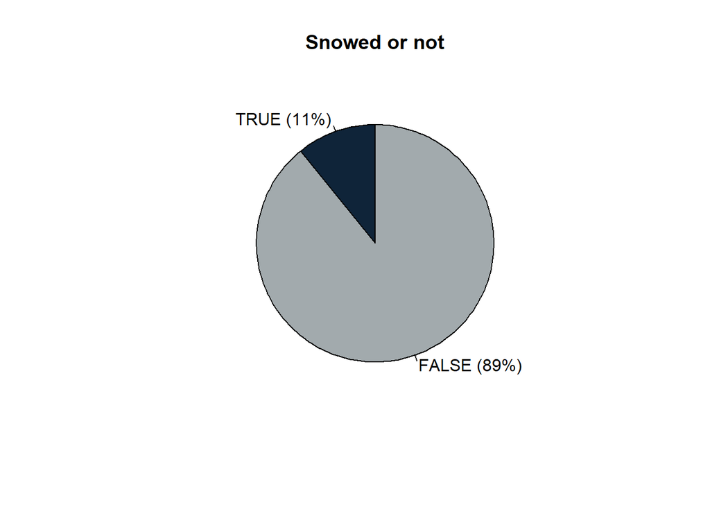

```r
# Pie chart
pie(tabp1, labels=paste(names(tabp1), " (", round(100*tabp1), "%)", sep=""),
    clockwise=T, col=c("#A2AAAD", "#0F2439"),
    main="Snowed or not")
```

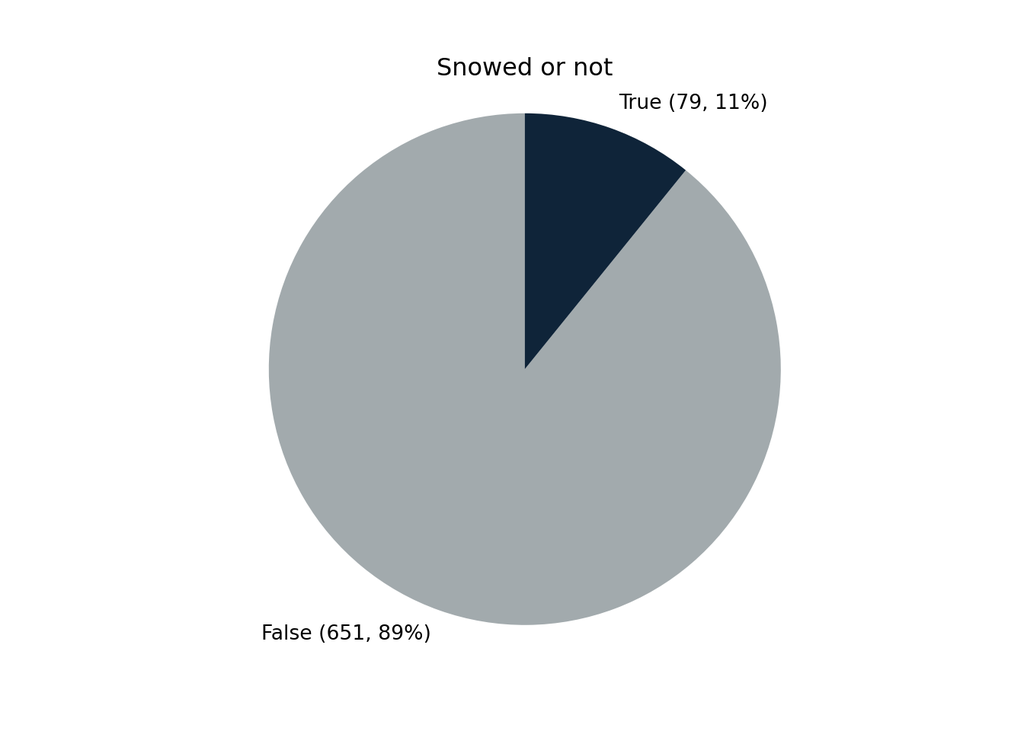

```python
# Pie chart
_ = plt.pie(tabp1, labels=[f"{name} ({count}, {round(100 * pct)}%)" for name, count, pct in zip(tabp1.index, tabf1, tabp1)],
    colors=["#A2AAAD", "#0F2439"],
    startangle=90, counterclock=True)
_ = plt.title("Snowed or not")
_ = plt.axis("equal")
plt.show()
```

Although ubiquitous, pie charts are generally not as effective as other types of charts because people have difficulty perceiving areas and angles. Instead, it is often cleaner to use one of the following alternatives.

### Bar/column chart

A **bar chart** displays the frequency of a small number of categories using the length of horizontal bars. A **column chart** presents the same information vertically. A few tips:

- If the names of the various categories are long, a bar chart is usually better, because the labels will have more space to print horizontally without crowding adjacent categories (as in the column chart). The same thing is true as the number of categories increases.
- If categories are truly unordered, then it often looks best use a bar chart and arrange the categories in descending order from largest to smallest. If categories are ordered, then a column chart that retains the natural ordering might be more intuitive.

In R, you can create them using the `barplot()` graphical function.

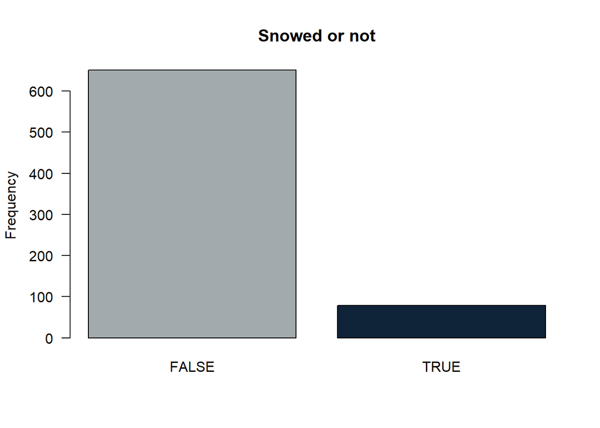

```r
# Column chart
barplot(tabf1, las=1, col=c("#A2AAAD", "#0F2439"),
        ylab="Frequency", xlab="",
        main="Snowed or not")
```

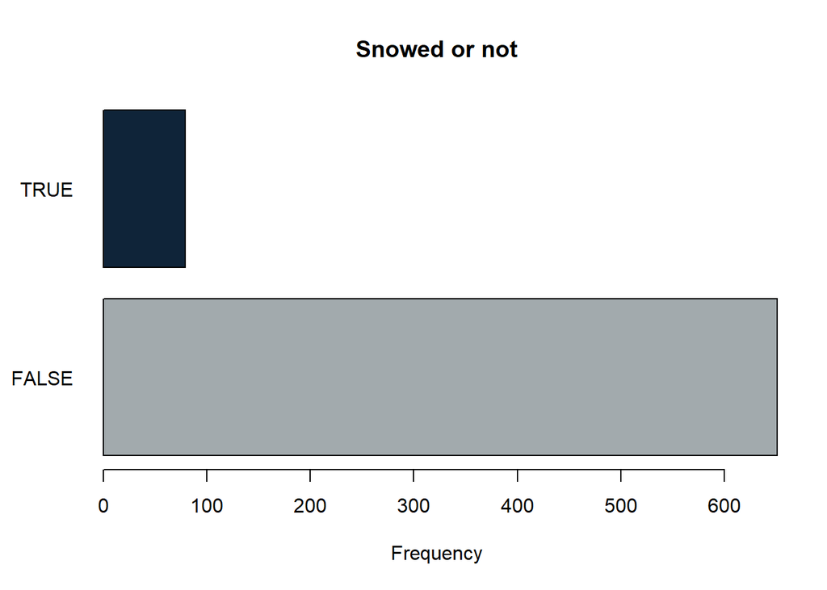

```r
# Bar chart
barplot(tabf1, horiz=T, las=1, col=c("#A2AAAD", "#0F2439"),
        ylab="", xlab="Frequency",
        main="Snowed or not")
```

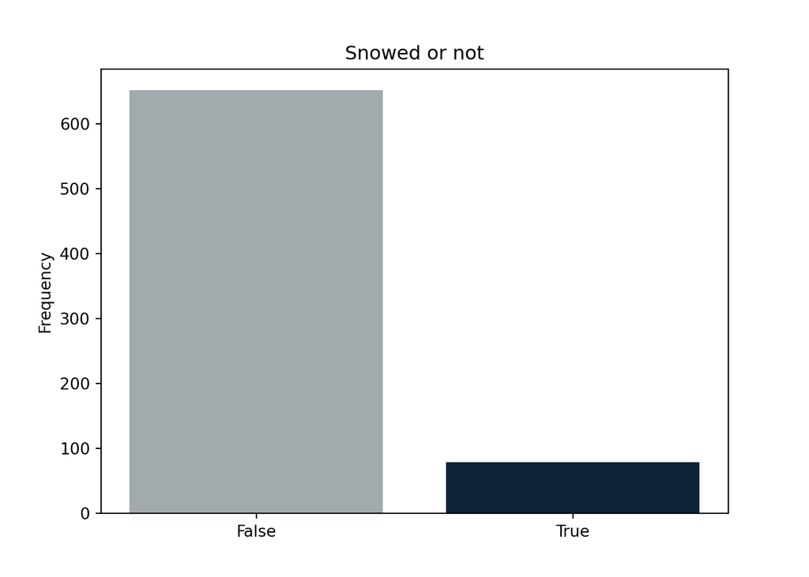

```python
# Column chart
_ = plt.bar(tabf1.index, tabf1, color=["#A2AAAD", "#0F2439"])
_ = plt.xlabel("")
_ = plt.ylabel("Frequency")
_ = plt.title("Snowed or not")
plt.show()
```

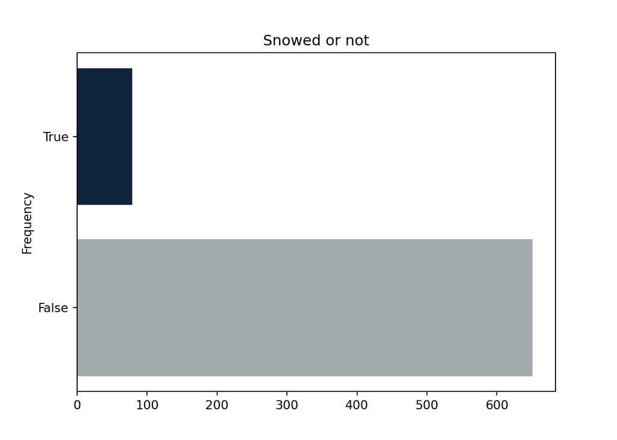

```python
# Column chart
_ = plt.barh(tabf1.index, tabf1, color=["#A2AAAD", "#0F2439"])
_ = plt.xlabel("")
_ = plt.ylabel("Frequency")
_ = plt.title("Snowed or not")
plt.show()
```

## Visualizing the distribution of a single continuous variable

When you are trying to visualize the distribution of one continuous variable, you have different options. The most common chart types are **box plots** and **histograms**. These charts display the distribution of observations of that variable.

### Box plot

A **box plot** (sometimes a box-and-whiskers plot) presents quartile-based measures of the distribution of a continuous variable. Usually, a box plot will contain the following information

- *IQR*: The box extends from the first quartile to the third quartile, spanning the interquartile range.
- *Median*: The line inside the box is the second quartile (median).
- *Outliers*: The whiskers usually extend to 1.5 times the IQR, and any observations beyond are considered to be outliers.

Like bar charts, box plots can be displayed horizontally or vertically. The default is vertically, but (like with bar charts) a horizontal alignment can often be easier to visualize, in part because the numerical values are shown horizontally like on a number line.

In R, box plots can be created using the `boxplot()` function.

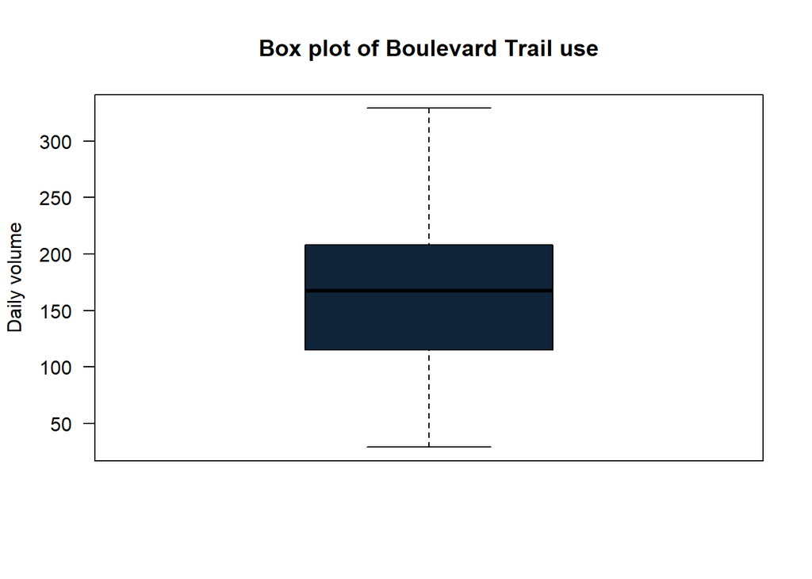

```r
# Vertical box plot
boxplot(dat$CountBL, las=1, col="#0F2439",
        ylab="Daily volume", main="Box plot of Boulevard Trail use")
```

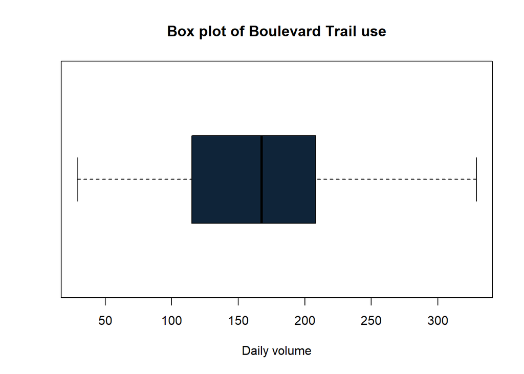

```r
# Horizontal box plot
boxplot(dat$CountBL, horizontal=T, las=1, col="#0F2439",
        xlab="Daily volume", main="Box plot of Boulevard Trail use")
```

In Python, box plots can be created using the `boxplot()` function.

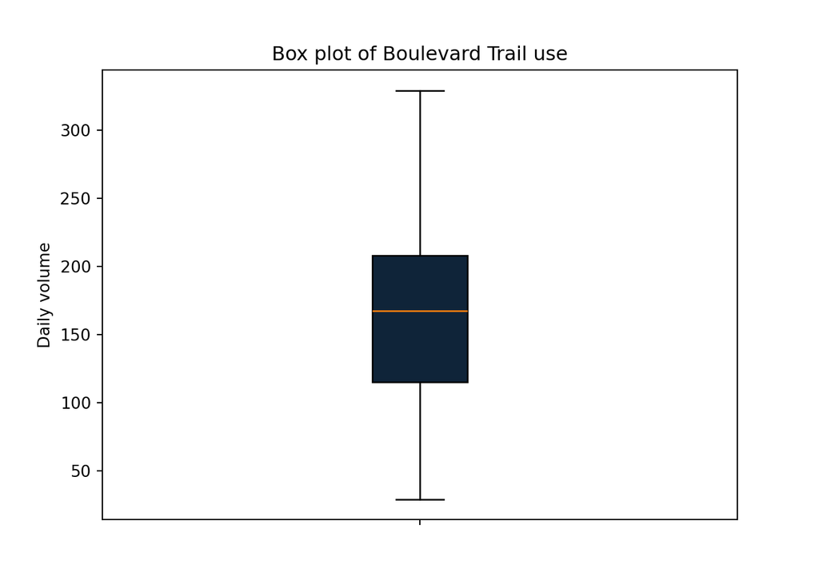

```python
# Vertical box plot
_ = plt.boxplot(dat['CountBL'], patch_artist=True, boxprops=dict(facecolor='#0F2439'))
_ = plt.ylabel("Daily volume")
_ = plt.title("Box plot of Boulevard Trail use")
_ = plt.xticks([1], [''])  # Remove x-axis label
plt.show()
```

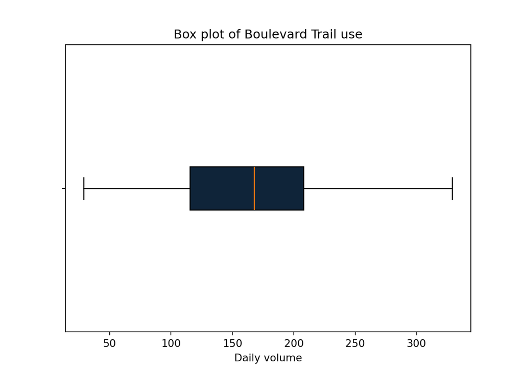

```python
# Horizontal box plot
_ = plt.boxplot(dat['CountBL'], vert=False,
        patch_artist=True, boxprops=dict(facecolor='#0F2439'))
_ = plt.xlabel("Daily volume")
_ = plt.title("Box plot of Boulevard Trail use")
_ = plt.yticks([1], [''])  # Remove y-axis label
plt.show()
```

### Histogram

**Histograms** look like column charts, but they are actually an approximation of the distribution of the continuous variable. (When a categorical variable has many ordered categories, a column chart begins to look very similar to a histogram.) They split the observations into several categories and then plot each category’s frequency or proportion.

In R, they can be created using the `hist()` graphical function. A few notes:

- You can accept the default categorization (which doesn’t look good in many cases), or you can specify the categorization using the `breaks` argument in the `hist()` function. See `?hist` for details.
- By default, the categories are right-closed. This means that a category `(14,16]` will include observations of 16 but not observations of 14.

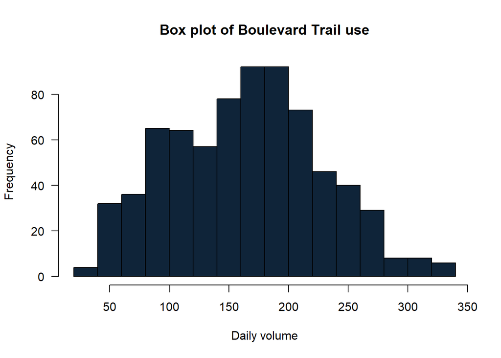

```r
# Histogram
hist(dat$CountBL, las=1, col="#0F2439",
     xlab="Daily volume", main="Box plot of Boulevard Trail use")
```

In Python, they can be created using the `hist()` graphical function.

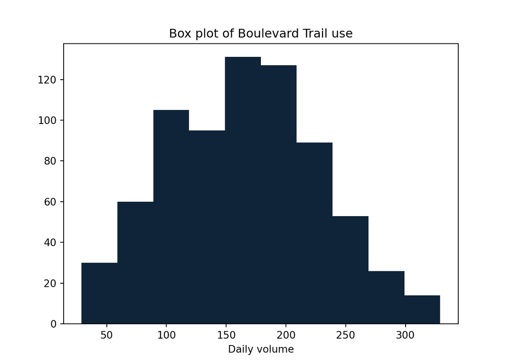

```python
# Histogram
_ = plt.hist(dat["CountBL"], color="#0F2439")
_ = plt.xlabel("Daily volume")
_ = plt.title("Box plot of Boulevard Trail use")
plt.show()
```

## Visually comparing or examining relationships among two variables

Sometimes you want to compare the composition or distribution of multiple (similar) variables or multiple groups on the same variable, or you want to examine potential relationships or associations between two variables.

### Two categorical variables

When you have two categorical variables, the same chart types that we have used can be extended to multiple groups: **bar/column charts**.

For instance, we could investigate the relationship between snowed and month. Let’s inspect the frequency/proportion of these variables.

In R, we can still use the same `table()` and `proportion()` functions. For proportions, we need to specify if we are dividing by row totals (`margin=1`), by column totals (`margin=2`), or both (`margin=c(1,2)`).

```r
# Tables
tabf2 <- table(dat$Snowed, dat$Month)
tabf2
```

```
        Jan Feb Mar Apr May Jun Jul Aug Sep Oct Nov Dec
  FALSE  47  41  49  58  61  60  62  62  60  60  52  39
  TRUE   15  15  13   2   1   0   0   0   0   2   8  23
```

```r
tabp2 <- proportions(tabf2, margin=2)
tabp2
```

```
               Jan        Feb        Mar        Apr        May        Jun
  FALSE 0.75806452 0.73214286 0.79032258 0.96666667 0.98387097 1.00000000
  TRUE  0.24193548 0.26785714 0.20967742 0.03333333 0.01612903 0.00000000

               Jul        Aug        Sep        Oct        Nov        Dec
  FALSE 1.00000000 1.00000000 1.00000000 0.96774194 0.86666667 0.62903226
  TRUE  0.00000000 0.00000000 0.00000000 0.03225806 0.13333333 0.37096774
```

In Python, we need to use the `crosstab()` function from `pandas`. For proportions, we need to specify if we are dividing by row totals (`normalize='index'`), by column totals (`normalize='columns'`), or both (`normalize='True'`).

```python
# Tables
tabf2 = pd.crosstab(dat['Snowed'], dat['Month'])
tabf2.index = ['False','True']
tabf2
tabp2 = pd.crosstab(dat['Snowed'], dat['Month'], normalize='columns')
tabp2.index = ['False','True']
tabp2
```

[output not shown]

**Bar and column charts** can be extended to show the composition of multiple groups or multiple categorical variables.

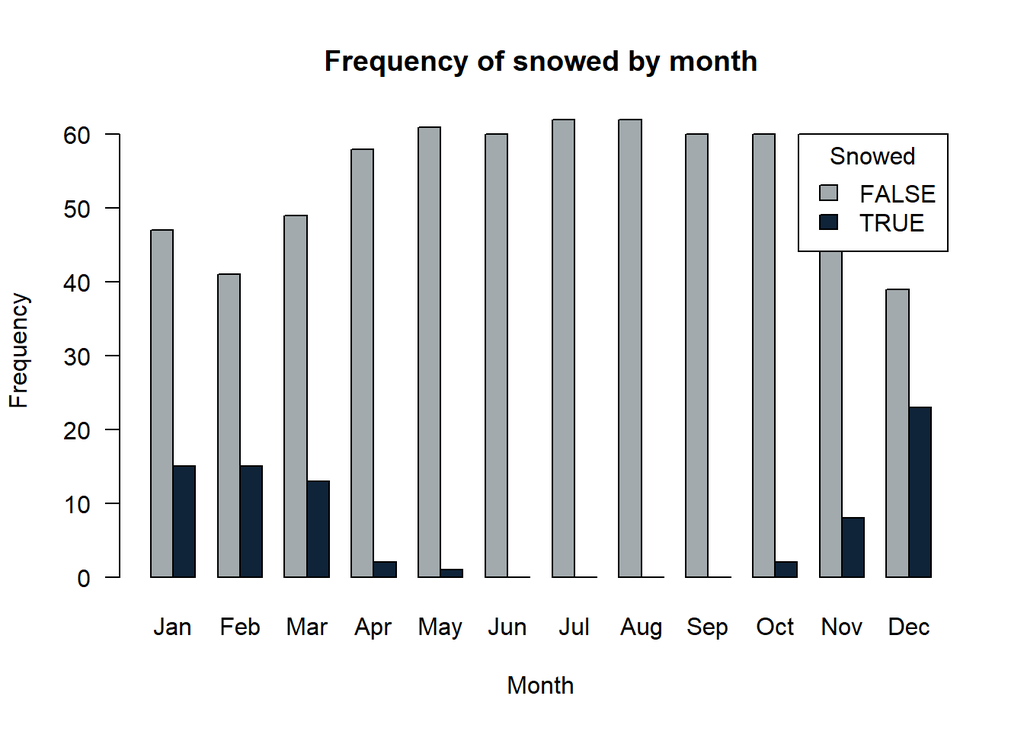

```r
# Multiple group column chart
barplot(tabf2, beside=T, las=1, col=c("#A2AAAD", "#0F2439"),
        ylab="Frequency", xlab="Month",
        main="Frequency of snowed by month",
        legend.text = row.names(tabf2), args.legend = list(title="Snowed"))
```

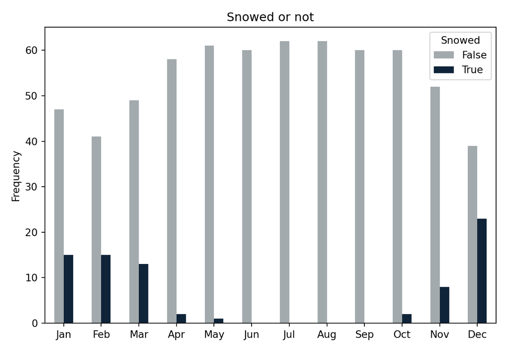

```python
# Multiple group column chart
_ = tabf2.T.plot(kind='bar', stacked=False, color=["#A2AAAD", "#0F2439"])
_ = plt.xlabel("")
_ = plt.ylabel("Frequency")
_ = plt.title("Snowed or not")
_ = plt.legend(title="Snowed")
_ = plt.tight_layout()
_ = plt.xticks(rotation=0)
plt.show()
```

**Stacked bar/column charts**, which place all the categories for a variable on each horizontal (or vertical) rectangle, are another option. They only work with a limited number of categories.

Stacked charts are especially useful if you are interested in comparing the proportion (and not frequency) of observations in each category across multiple variables.

Note: Stacked bar charts usually are easier to visualize than stacked column charts, because charts are usually wider than they are tall and it is easier to differentiate categories when they are longer and narrower (instead of shorter and fatter).

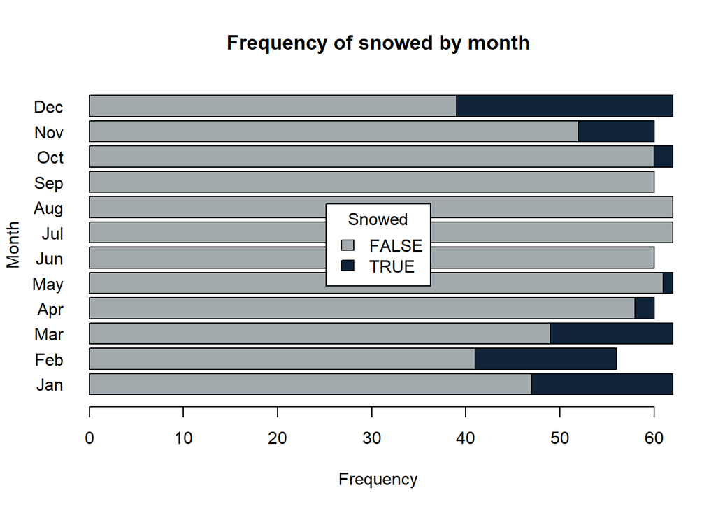

```r
# Stacked multiple group bar chart of frequencies
barplot(tabf2, horiz=T, las=1, col=c("#A2AAAD", "#0F2439"),
        xlab="Frequency", ylab="Month",
        main="Frequency of snowed by month",
        legend.text = row.names(tabf2),
        args.legend = list(x="center", title="Snowed", horiz=F))
```

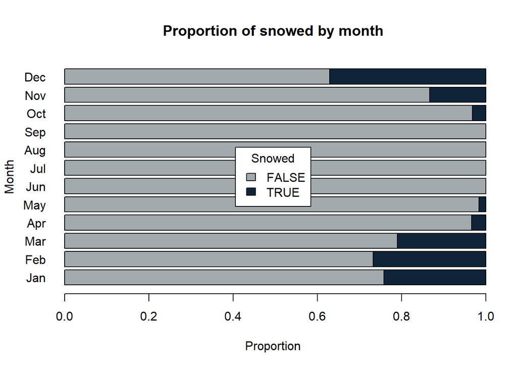

```r
# Stacked multiple group bar chart of proportions
barplot(tabp2, horiz=T, las=1, col=c("#A2AAAD", "#0F2439"),
        xlab="Proportion", ylab="Month",
        main="Proportion of snowed by month",
        legend.text = row.names(tabp2),
        args.legend = list(x="center", title="Snowed", horiz=F))
```

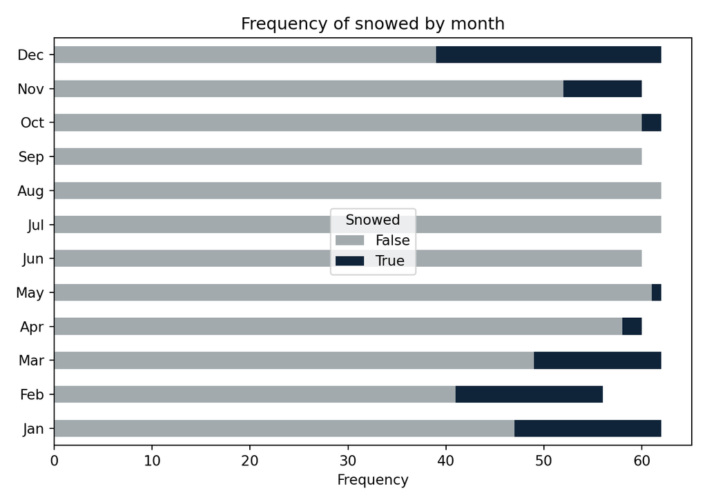

```python
# Stacked multiple group column chart of frequencies
_ = tabf2.T.plot(kind='barh', stacked=True, color=["#A2AAAD", "#0F2439"])
_ = plt.xlabel("Frequency")
_ = plt.ylabel("")
_ = plt.title("Frequency of snowed by month")
_ = plt.legend(title="Snowed", loc='center')
_ = plt.tight_layout()
plt.show()
```

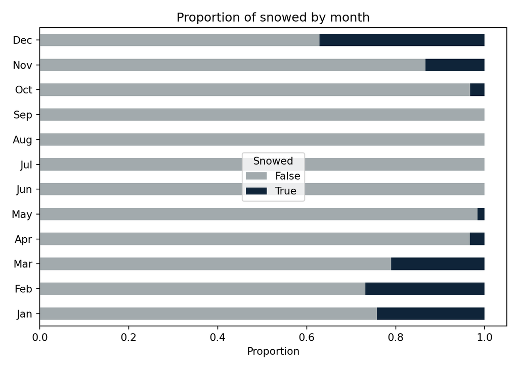

```python
# Stacked multiple group column chart of proportions
_ = tabp2.T.plot(kind='barh', stacked=True, color=["#A2AAAD", "#0F2439"])
_ = plt.xlabel("Proportion")
_ = plt.ylabel("")
_ = plt.title("Proportion of snowed by month")
_ = plt.legend(title="Snowed", loc='center')
_ = plt.tight_layout()
plt.show()
```

### One continuous variable and one categorical variable

For one continuous variable and one categorical variables, **box plots** can also be extended to show the distribution of a continuous variable across groups of the categorical variable. Once again, vertical and horizontal options are available.

In R, with multiple groups, you must use the argument `formula=y~grp`.

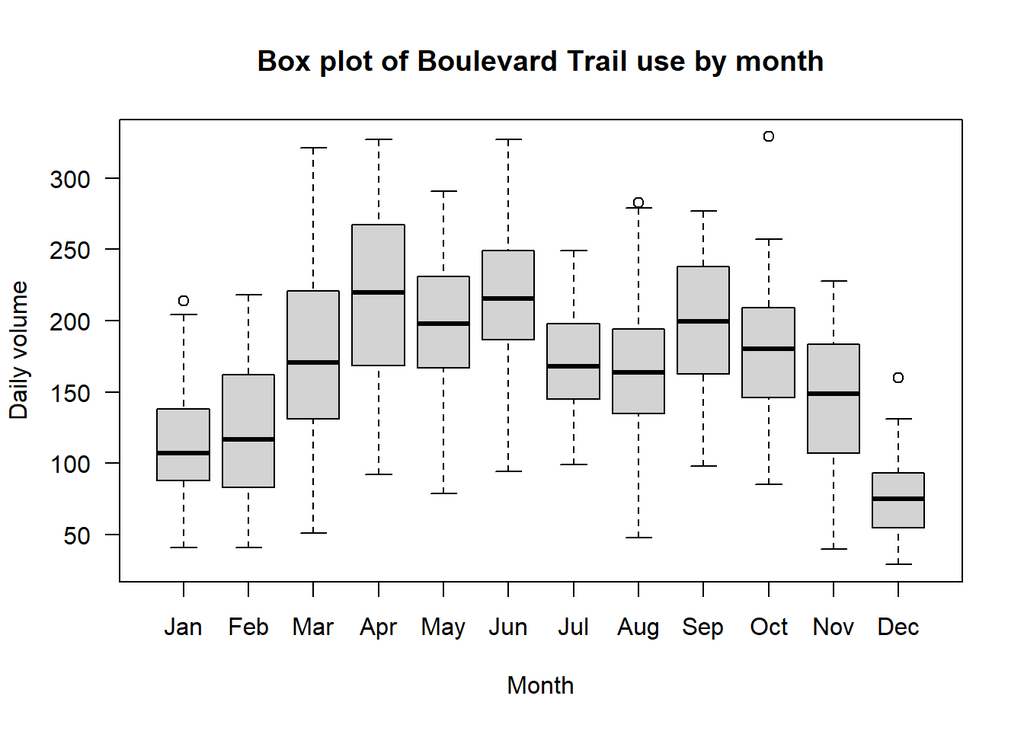

```r
# Vertical box plot
boxplot(formula=CountBL~Month, data=dat, las=1,
        xlab="Month", ylab="Daily volume", main="Box plot of Boulevard Trail use by month")
```

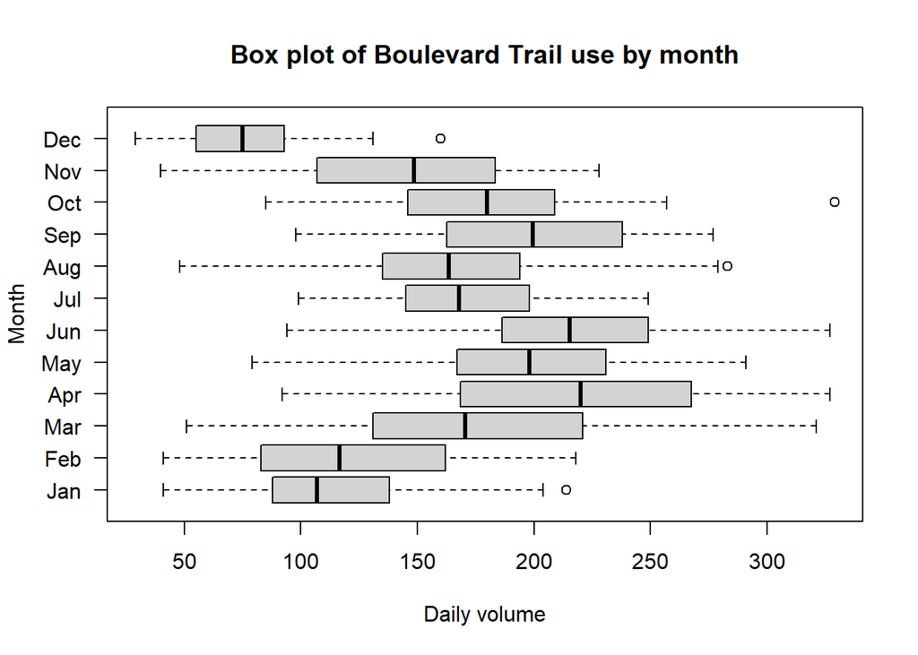

```r
# Horizontal box plot
boxplot(formula=CountBL~Month, data=dat, horizontal=T, las=1,
        ylab="Month", xlab="Daily volume",
        main="Box plot of Boulevard Trail use by month")
```

In Python, with multiple groups, you must use the `boxplot()` function from `seaborn`.

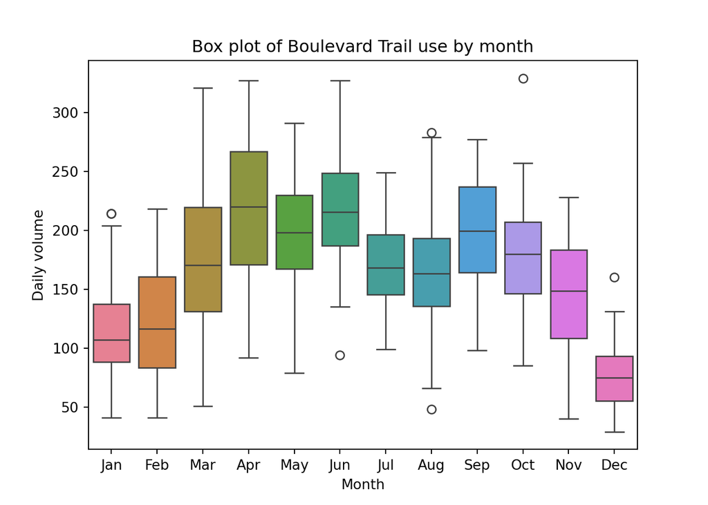

```python
# Vertical box plot
_ = sns.boxplot(x="Month", y="CountBL", data=dat,
        hue="Month", legend=False)
_ = plt.xlabel("Month")
_ = plt.ylabel("Daily volume")
_ = plt.title("Box plot of Boulevard Trail use by month")
plt.show()
```

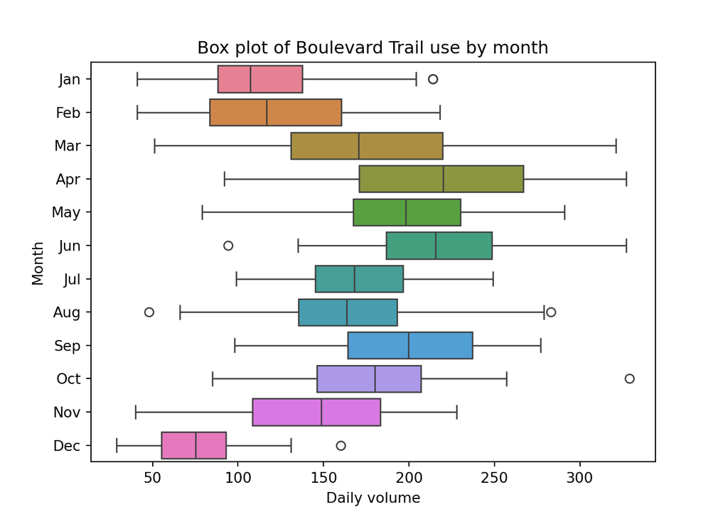

```python
# Horizontal box plot
_ = sns.boxplot(y="Month", x="CountBL", data=dat, orient='h',
        hue="Month", legend=False)
_ = plt.ylabel("Month")
_ = plt.xlabel("Daily volume")
_ = plt.title("Box plot of Boulevard Trail use by month")
plt.show()
```

### Two continuous variables

Often, we are interested in visualizing the association or relationship between two variables. In these cases, we can use a **scatter diagram** (or scatterplot), which depicts the actual observations on a two dimensional plane, with each point’s specific (x,y) coordinates determined by the values of the two variables. In this way, a scatterplot gives us more rich information than a simple measure of association like Pearson’s correlation parameter.

In R, they can be created using the `plot()` function. You can use different point characters by changing the `pch=` argument. Look at `?points` for details on what each `pch` number will show.

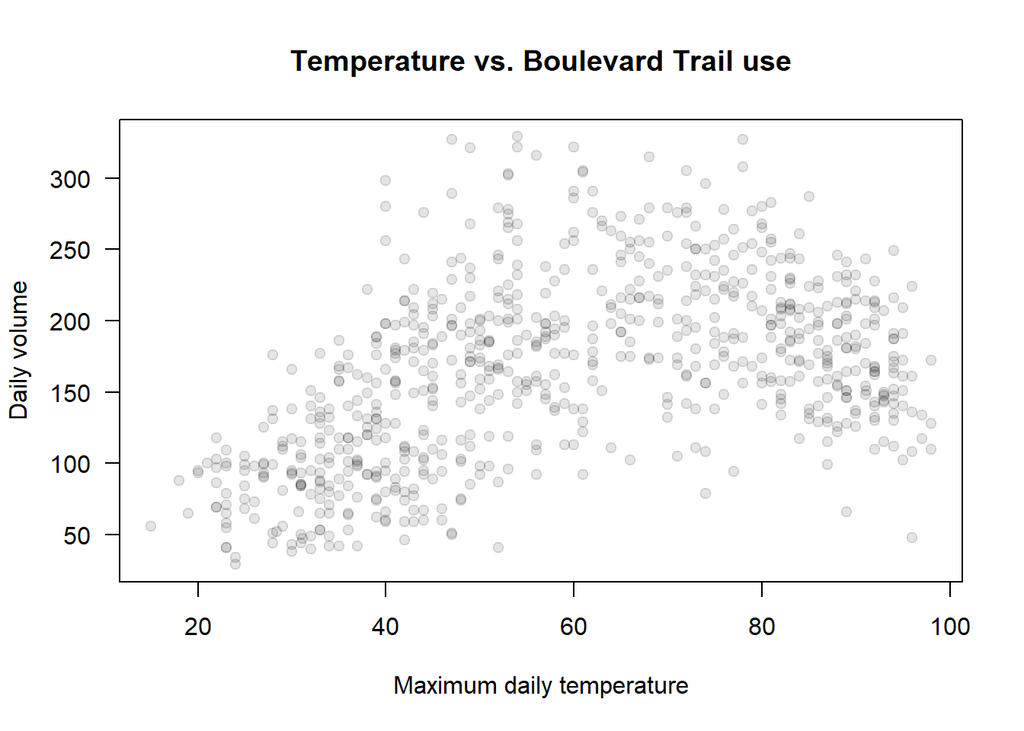

```r
# Scatter plot
plot(x=dat$Temp_Max, y=dat$CountBL, pch=19, las=1, col=rgb(0,0,0,0.1),
     xlab="Maximum daily temperature", ylab="Daily volume",
     main="Temperature vs. Boulevard Trail use")
```

In Python, they can be created using the `scatter()` function.

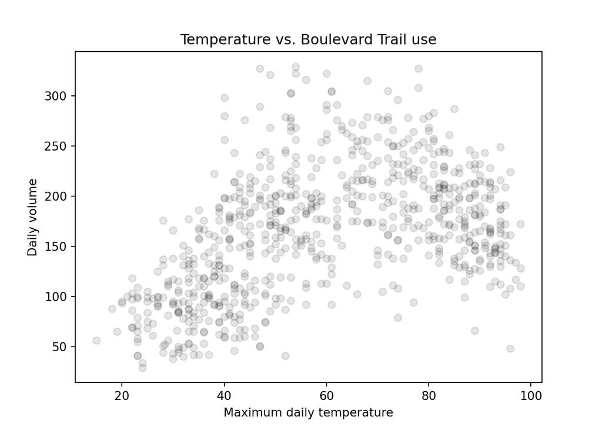

```python
# Scatter plot
_ = plt.scatter(dat["Temp_Max"], dat["CountBL"],
        color='black', alpha=0.1)
_ = plt.xlabel("Maximum daily temperature")
_ = plt.ylabel("Daily volume")
_ = plt.title("Temperature vs. Boulevard Trail use")
plt.show()
```

### One continuous variable and one time variable

A special plot is particularly useful when one of the variables is time. **Line charts** depict changes in one variable over any unit of time.

In R, they are created using a combination of the `plot()` function followed by the `line()` function. (We will discuss analyzing these types of *time series data* in a later tutorial.) Let’s extract one month of data to plot.

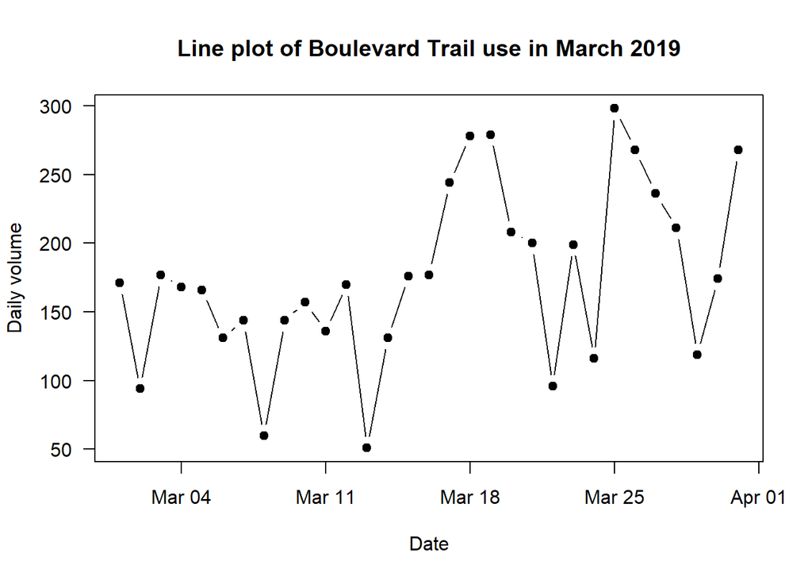

```r
# Extract one month in 2019
temp1 <- dat[dat$Year=="2019" & dat$Month=="Mar",c("Date", "CountBL")]

# Line chart
plot(temp1$Date, temp1$CountBL, las=1, type="b", pch=19,
  xlab="Date", ylab="Daily volume",
  main="Line plot of Boulevard Trail use in March 2019")
```

Now, let’s extract the same month one year earlier, and compare. Technically, we want dates that are $52 \times 7 = 364$ days earlier, to align weekends. To add another line to the same plot, use the `lines()` function.

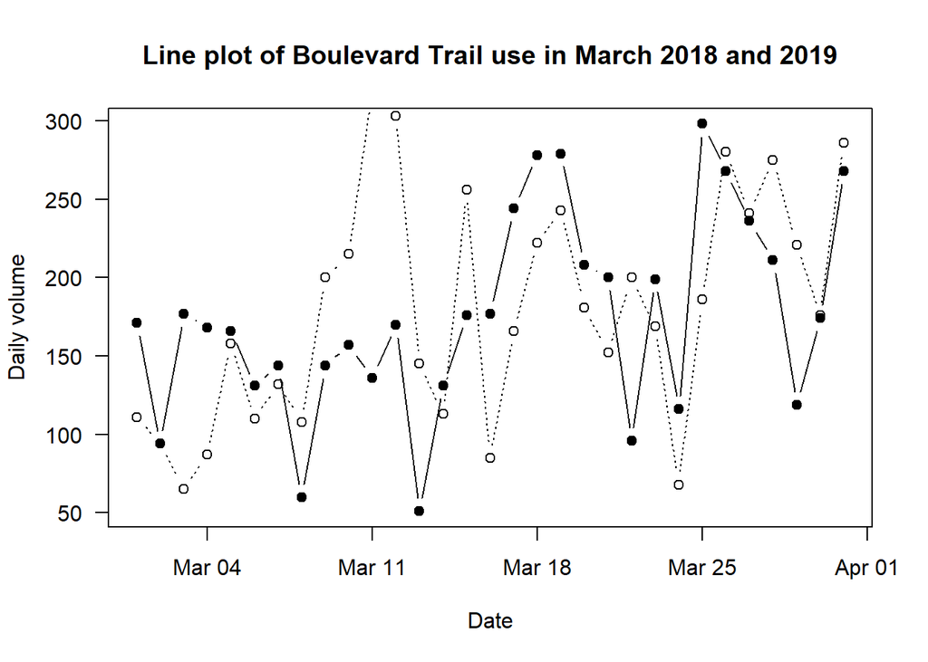

```r
# Extract same information, one year previous
temp2 <- dat[dat$Date %in% (temp1$Date-52*7),c("Date", "CountBL")]
names(temp2) <- c("Date", "CountBL_2018")
temp2$Date <- temp2$Date + 52*7
temp <- merge(temp1, temp2, by="Date", all.x=T, all.y=T)

# Line chart
plot(temp$Date, temp$CountBL, las=1, type="b", pch=19,
  xlab="Date", ylab="Daily volume",
  main="Line plot of Boulevard Trail use in March 2018 and 2019")
lines(temp$Date, temp$CountBL_2018, type="b", pch=1, lty=3)
```

In Python, use the `plot()` function.

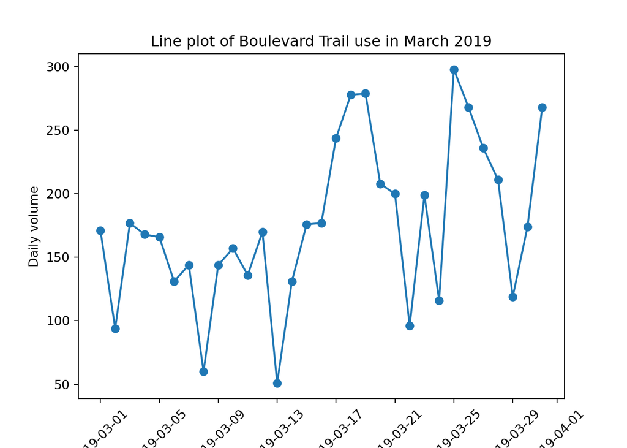

```python
# Extract one month in 2019
temp1 = dat.loc[(dat["Year"]=="2019") & (dat["Month"]=="Mar")][["Date", "CountBL"]]

# Line chart
_ = plt.plot(temp1["Date"], temp1["CountBL"], marker='o', linestyle='-')
_ = plt.xlabel("Date")
_ = plt.ylabel("Daily volume")
_ = plt.title("Line plot of Boulevard Trail use in March 2019")
_ = plt.xticks(rotation=45)
plt.show()
```

Now, let’s extract the same month one year earlier, and compare. Technically, we want dates that are $52 \times 7 = 364$ days earlier, to align weekends. To add another line to the same plot, use the `plot()` and `scatter` functions.

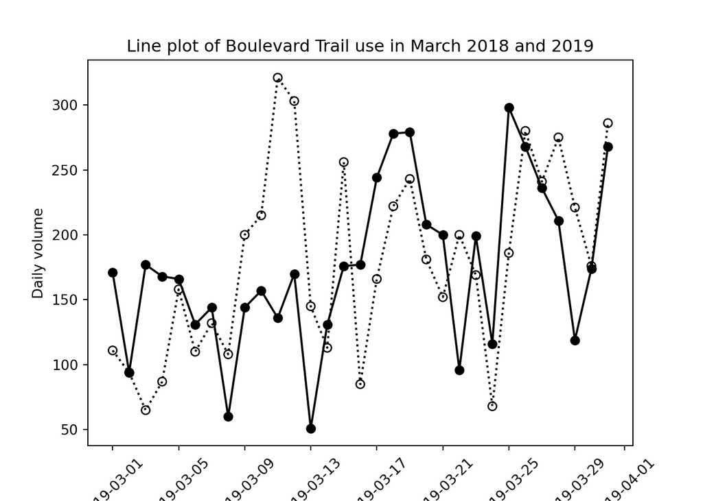

```python
# Extract same information, one year previous
target_dates = temp1["Date"] - pd.to_timedelta(52 * 7, unit="d")
temp2 = dat[dat["Date"].isin(target_dates)][["Date", "CountBL"]]
del target_dates
target_dates = temp2["Date"] + pd.to_timedelta(52 * 7, unit="d")
temp2["Date"] = target_dates
del target_dates
temp2.columns = ["Date", "CountBL_2018"]
temp = pd.merge(temp1, temp2, on="Date", how="outer")

# Line chart
_ = plt.plot(temp["Date"], temp["CountBL"], marker='o', linestyle='-', color="black", label="2019")
_ = plt.plot(temp["Date"], temp["CountBL_2018"], linestyle=':', color="black", label="2018")
_ = plt.scatter(temp['Date'], temp["CountBL_2018"], facecolors='none', edgecolors="black", marker='o')
_ = plt.xlabel("Date")
_ = plt.ylabel("Daily volume")
_ = plt.title("Line plot of Boulevard Trail use in March 2018 and 2019")
_ = plt.xticks(rotation=45)
plt.show()
```

## Other tips

### General graphical tips

There are many other ways to customize and improve the appearance of these graphics in R. Look up graphical parameters by searching for `?par`. Here are a few links to websites that discuss these parameters:

- [Graphical Parameters in R](https://www.datacamp.com/doc/r/parameters) from DataCamp.
- [par() Graphical Parameters](http://www.gastonsanchez.com/r-graphical-parameters-cheatsheet.pdf) from Gaston Sanchez.
- [plot: Generic X-Y Plotting](https://www.rdocumentation.org/packages/graphics/versions/3.6.2/topics/plot) help from Rdocumentation.

There are many resources to help you create pretty and professional graphics in Python. For instance:

- Different [plot types](https://matplotlib.org/stable/plot_types/index.html) and [examples](https://matplotlib.org/stable/gallery/index.html) from mathplotlib.
- [Cheatsheets](https://matplotlib.org/cheatsheets/) for plotting from mathplotlib.

### The Grammar of Graphics

A popular guide to producing figures is known as the *grammar of graphics*. This is based on the book *The Grammar of Graphics* by Leland Wilkinson ([link to publisher](https://link.springer.com/book/10.1007/0-387-28695-0), [link to Amazon](https://www.amazon.com/Grammar-Graphics-Statistics-Computing/dp/0387245448)) and [subsequent work](https://vita.had.co.nz/papers/layered-grammar.html) by Hadley Wickham.

In R, the grammar of graphics is implemented in the [**`ggplot2`** package](https://ggplot2.tidyverse.org/). There is [a handy cheatsheet](https://github.com/rstudio/cheatsheets/blob/master/data-visualization.pdf) on how to create and modify each of the types of charts in ggplot2.

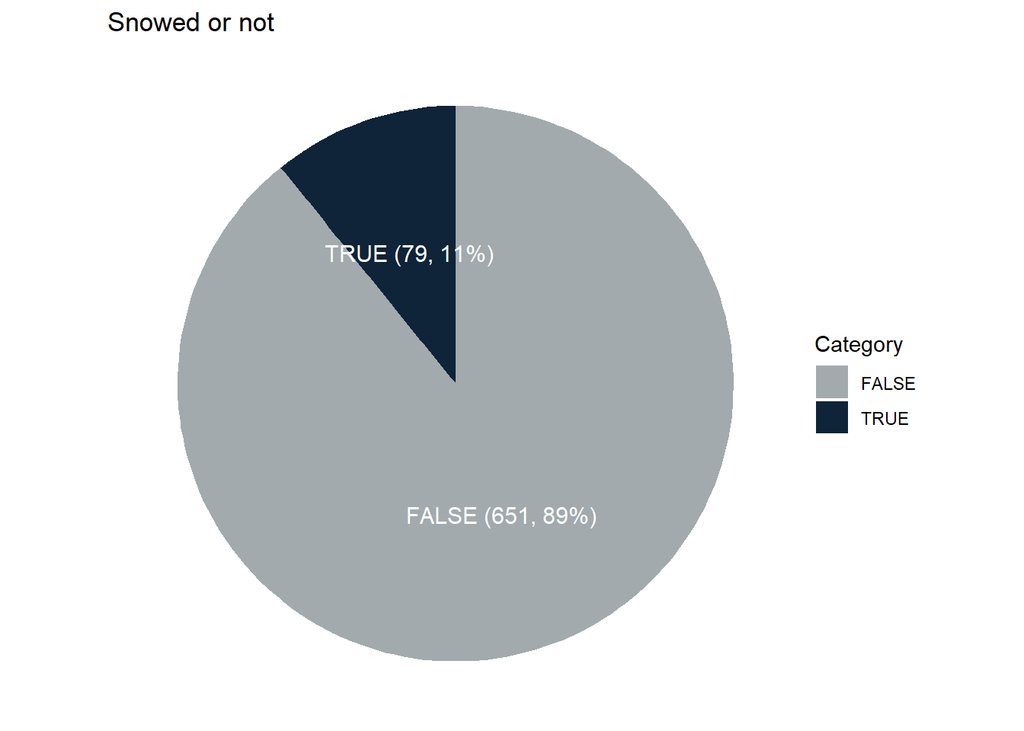

```r
# Load packages
library("ggplot2")

# Pie chart
df1 <- data.frame(Category=names(tabp1), Proportion=as.numeric(tabp1), Count=as.integer(tabf1))
df1$Label <- paste0(df1$Category, " (", df1$Count, ", ", round(100*df1$Proportion), "%)")
ggplot(data=df1, mapping=aes(x="", y=Proportion, fill=Category)) +
  geom_bar(stat="identity", width=1) +
  coord_polar(theta="y", start=0, direction=-1) + # clockwise
  scale_fill_manual(values=c("#A2AAAD", "#0F2439")) +
  geom_text(aes(label=Label), position=position_stack(vjust=0.5), size=4, color="white") +
  labs(title="Snowed or not", fill="Category") +
  theme_void()
```

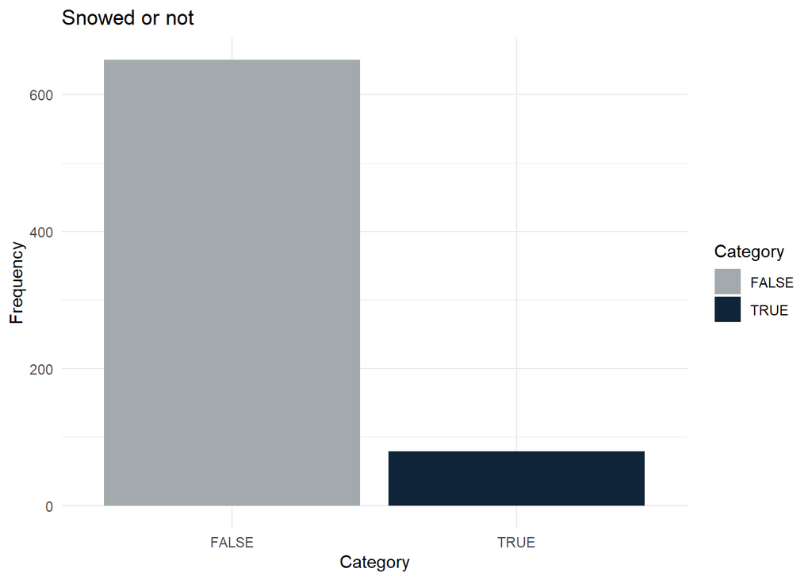

```r
rm(df1)

# Column chart
df1 <- data.frame(Category=names(tabf1), Frequency=as.integer(tabf1))
ggplot(df1, aes(x=Category, y=Frequency, fill=Category)) +
  geom_bar(stat="identity") +
  scale_fill_manual(values=c("#A2AAAD", "#0F2439")) +
  labs(title="Snowed or not") +
  theme_minimal()
```

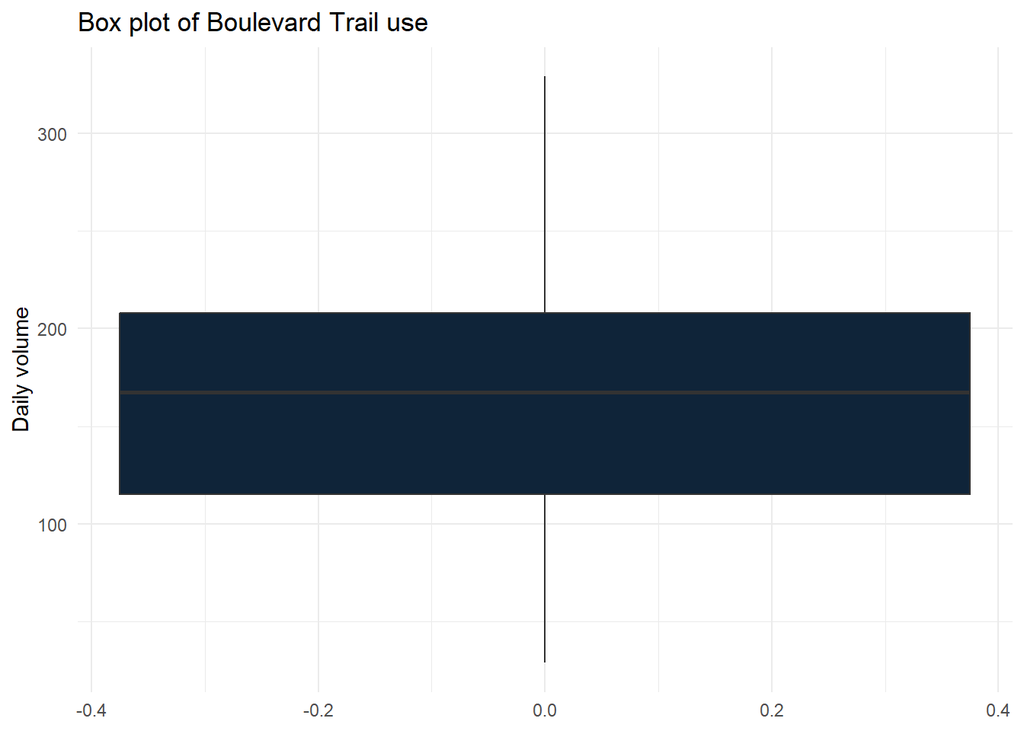

```r
rm(df1)

# Box plot
ggplot(dat, aes(y=CountBL)) +
  geom_boxplot(fill="#0F2439") +
  labs(y="Daily volume",
    title="Box plot of Boulevard Trail use") +
  theme_minimal()
```